# Risk Factor Analysis

## Outcome Variable

**Outcome Variable:** ever_swasted

## Predictor Variables

**Intervention Variable:** birthwt

**Adjustment Set:**

- arm
- sex
- W_mage
- meducyrs
- feducyrs
- vagbrth
- single
- brthmon
- W_parity
- delta_W_mage
- delta_meducyrs
- delta_feducyrs
- delta_vagbrth
- delta_single
- delta_brthmon
- delta_W_parity

## Stratifying Variables

The analysis was stratified on these variable(s):

- agecat
- studyid
- country

## Data Summary

| agecat | studyid | country | birthwt | ever_swasted | n_cell | n |
| --- | --- | --- | --- | --- | --- | --- |
| 0-24 months (no birth wast) | ki0047075b-MAL-ED | BANGLADESH | Normal or high birthweight | 0 | 195 | 257 |
| 0-24 months (no birth wast) | ki0047075b-MAL-ED | BANGLADESH | Normal or high birthweight | 1 | 9 | 257 |
| 0-24 months (no birth wast) | ki0047075b-MAL-ED | BANGLADESH | Low birth weight | 0 | 50 | 257 |
| 0-24 months (no birth wast) | ki0047075b-MAL-ED | BANGLADESH | Low birth weight | 1 | 3 | 257 |
| 0-24 months (no birth wast) | ki0047075b-MAL-ED | BRAZIL | Normal or high birthweight | 0 | 217 | 232 |
| 0-24 months (no birth wast) | ki0047075b-MAL-ED | BRAZIL | Normal or high birthweight | 1 | 3 | 232 |
| 0-24 months (no birth wast) | ki0047075b-MAL-ED | BRAZIL | Low birth weight | 0 | 12 | 232 |
| 0-24 months (no birth wast) | ki0047075b-MAL-ED | BRAZIL | Low birth weight | 1 | 0 | 232 |
| 0-24 months (no birth wast) | ki0047075b-MAL-ED | INDIA | Normal or high birthweight | 0 | 193 | 238 |
| 0-24 months (no birth wast) | ki0047075b-MAL-ED | INDIA | Normal or high birthweight | 1 | 9 | 238 |
| 0-24 months (no birth wast) | ki0047075b-MAL-ED | INDIA | Low birth weight | 0 | 36 | 238 |
| 0-24 months (no birth wast) | ki0047075b-MAL-ED | INDIA | Low birth weight | 1 | 0 | 238 |
| 0-24 months (no birth wast) | ki0047075b-MAL-ED | NEPAL | Normal or high birthweight | 0 | 210 | 232 |
| 0-24 months (no birth wast) | ki0047075b-MAL-ED | NEPAL | Normal or high birthweight | 1 | 1 | 232 |
| 0-24 months (no birth wast) | ki0047075b-MAL-ED | NEPAL | Low birth weight | 0 | 21 | 232 |
| 0-24 months (no birth wast) | ki0047075b-MAL-ED | NEPAL | Low birth weight | 1 | 0 | 232 |
| 0-24 months (no birth wast) | ki0047075b-MAL-ED | PERU | Normal or high birthweight | 0 | 278 | 299 |
| 0-24 months (no birth wast) | ki0047075b-MAL-ED | PERU | Normal or high birthweight | 1 | 3 | 299 |
| 0-24 months (no birth wast) | ki0047075b-MAL-ED | PERU | Low birth weight | 0 | 18 | 299 |
| 0-24 months (no birth wast) | ki0047075b-MAL-ED | PERU | Low birth weight | 1 | 0 | 299 |
| 0-24 months (no birth wast) | ki0047075b-MAL-ED | SOUTH AFRICA | Normal or high birthweight | 0 | 277 | 308 |
| 0-24 months (no birth wast) | ki0047075b-MAL-ED | SOUTH AFRICA | Normal or high birthweight | 1 | 10 | 308 |
| 0-24 months (no birth wast) | ki0047075b-MAL-ED | SOUTH AFRICA | Low birth weight | 0 | 20 | 308 |
| 0-24 months (no birth wast) | ki0047075b-MAL-ED | SOUTH AFRICA | Low birth weight | 1 | 1 | 308 |
| 0-24 months (no birth wast) | ki0047075b-MAL-ED | TANZANIA, UNITED REPUBLIC OF | Normal or high birthweight | 0 | 126 | 135 |
| 0-24 months (no birth wast) | ki0047075b-MAL-ED | TANZANIA, UNITED REPUBLIC OF | Normal or high birthweight | 1 | 2 | 135 |
| 0-24 months (no birth wast) | ki0047075b-MAL-ED | TANZANIA, UNITED REPUBLIC OF | Low birth weight | 0 | 7 | 135 |
| 0-24 months (no birth wast) | ki0047075b-MAL-ED | TANZANIA, UNITED REPUBLIC OF | Low birth weight | 1 | 0 | 135 |
| 0-24 months (no birth wast) | ki1000108-CMC-V-BCS-2002 | INDIA | Normal or high birthweight | 0 | 278 | 368 |
| 0-24 months (no birth wast) | ki1000108-CMC-V-BCS-2002 | INDIA | Normal or high birthweight | 1 | 50 | 368 |

[output cut: 318 more lines]

The following strata were considered:

- agecat: 0-24 months (no birth wast), studyid: ki0047075b-MAL-ED, country: BANGLADESH
- agecat: 0-24 months (no birth wast), studyid: ki0047075b-MAL-ED, country: BRAZIL
- agecat: 0-24 months (no birth wast), studyid: ki0047075b-MAL-ED, country: INDIA
- agecat: 0-24 months (no birth wast), studyid: ki0047075b-MAL-ED, country: NEPAL
- agecat: 0-24 months (no birth wast), studyid: ki0047075b-MAL-ED, country: PERU
- agecat: 0-24 months (no birth wast), studyid: ki0047075b-MAL-ED, country: SOUTH AFRICA
- agecat: 0-24 months (no birth wast), studyid: ki0047075b-MAL-ED, country: TANZANIA, UNITED REPUBLIC OF
- agecat: 0-24 months (no birth wast), studyid: ki1000108-CMC-V-BCS-2002, country: INDIA
- agecat: 0-24 months (no birth wast), studyid: ki1000108-IRC, country: INDIA
- agecat: 0-24 months (no birth wast), studyid: ki1000109-EE, country: PAKISTAN
- agecat: 0-24 months (no birth wast), studyid: ki1000109-ResPak, country: PAKISTAN
- agecat: 0-24 months (no birth wast), studyid: ki1000304b-SAS-CompFeed, country: INDIA
- agecat: 0-24 months (no birth wast), studyid: ki1017093-NIH-Birth, country: BANGLADESH
- agecat: 0-24 months (no birth wast), studyid: ki1017093b-PROVIDE, country: BANGLADESH
- agecat: 0-24 months (no birth wast), studyid: ki1017093c-NIH-Crypto, country: BANGLADESH
- agecat: 0-24 months (no birth wast), studyid: ki1066203-TanzaniaChild2, country: TANZANIA, UNITED REPUBLIC OF
- agecat: 0-24 months (no birth wast), studyid: ki1101329-Keneba, country: GAMBIA
- agecat: 0-24 months (no birth wast), studyid: ki1114097-CMIN, country: BANGLADESH
- agecat: 0-24 months (no birth wast), studyid: ki1114097-CMIN, country: BRAZIL
- agecat: 0-24 months (no birth wast), studyid: ki1114097-CMIN, country: GUINEA-BISSAU
- agecat: 0-24 months (no birth wast), studyid: ki1114097-CMIN, country: PERU
- agecat: 0-24 months (no birth wast), studyid: ki1114097-CONTENT, country: PERU
- agecat: 0-24 months (no birth wast), studyid: ki1119695-PROBIT, country: BELARUS
- agecat: 0-24 months (no birth wast), studyid: ki1126311-ZVITAMBO, country: ZIMBABWE
- agecat: 0-24 months (no birth wast), studyid: ki1135781-COHORTS, country: GUATEMALA
- agecat: 0-24 months (no birth wast), studyid: ki1135781-COHORTS, country: INDIA
- agecat: 0-24 months (no birth wast), studyid: ki1135781-COHORTS, country: PHILIPPINES
- agecat: 0-24 months (no birth wast), studyid: kiGH5241-JiVitA-3, country: BANGLADESH
- agecat: 0-24 months (no birth wast), studyid: kiGH5241-JiVitA-4, country: BANGLADESH
- agecat: 0-6 months (no birth wast), studyid: ki0047075b-MAL-ED, country: BANGLADESH
- agecat: 0-6 months (no birth wast), studyid: ki0047075b-MAL-ED, country: BRAZIL
- agecat: 0-6 months (no birth wast), studyid: ki0047075b-MAL-ED, country: INDIA
- agecat: 0-6 months (no birth wast), studyid: ki0047075b-MAL-ED, country: NEPAL
- agecat: 0-6 months (no birth wast), studyid: ki0047075b-MAL-ED, country: PERU
- agecat: 0-6 months (no birth wast), studyid: ki0047075b-MAL-ED, country: SOUTH AFRICA
- agecat: 0-6 months (no birth wast), studyid: ki0047075b-MAL-ED, country: TANZANIA, UNITED REPUBLIC OF
- agecat: 0-6 months (no birth wast), studyid: ki1000108-CMC-V-BCS-2002, country: INDIA
- agecat: 0-6 months (no birth wast), studyid: ki1000108-IRC, country: INDIA
- agecat: 0-6 months (no birth wast), studyid: ki1000109-EE, country: PAKISTAN
- agecat: 0-6 months (no birth wast), studyid: ki1000109-ResPak, country: PAKISTAN
- agecat: 0-6 months (no birth wast), studyid: ki1000304b-SAS-CompFeed, country: INDIA
- agecat: 0-6 months (no birth wast), studyid: ki1017093-NIH-Birth, country: BANGLADESH
- agecat: 0-6 months (no birth wast), studyid: ki1017093b-PROVIDE, country: BANGLADESH
- agecat: 0-6 months (no birth wast), studyid: ki1017093c-NIH-Crypto, country: BANGLADESH
- agecat: 0-6 months (no birth wast), studyid: ki1066203-TanzaniaChild2, country: TANZANIA, UNITED REPUBLIC OF
- agecat: 0-6 months (no birth wast), studyid: ki1101329-Keneba, country: GAMBIA
- agecat: 0-6 months (no birth wast), studyid: ki1114097-CMIN, country: BANGLADESH
- agecat: 0-6 months (no birth wast), studyid: ki1114097-CMIN, country: BRAZIL
- agecat: 0-6 months (no birth wast), studyid: ki1114097-CMIN, country: GUINEA-BISSAU
- agecat: 0-6 months (no birth wast), studyid: ki1114097-CMIN, country: PERU
- agecat: 0-6 months (no birth wast), studyid: ki1114097-CONTENT, country: PERU
- agecat: 0-6 months (no birth wast), studyid: ki1119695-PROBIT, country: BELARUS
- agecat: 0-6 months (no birth wast), studyid: ki1126311-ZVITAMBO, country: ZIMBABWE
- agecat: 0-6 months (no birth wast), studyid: ki1135781-COHORTS, country: GUATEMALA
- agecat: 0-6 months (no birth wast), studyid: ki1135781-COHORTS, country: INDIA
- agecat: 0-6 months (no birth wast), studyid: ki1135781-COHORTS, country: PHILIPPINES
- agecat: 0-6 months (no birth wast), studyid: kiGH5241-JiVitA-3, country: BANGLADESH
- agecat: 0-6 months (no birth wast), studyid: kiGH5241-JiVitA-4, country: BANGLADESH
- agecat: 6-24 months, studyid: ki0047075b-MAL-ED, country: BANGLADESH
- agecat: 6-24 months, studyid: ki0047075b-MAL-ED, country: BRAZIL
- agecat: 6-24 months, studyid: ki0047075b-MAL-ED, country: INDIA
- agecat: 6-24 months, studyid: ki0047075b-MAL-ED, country: NEPAL
- agecat: 6-24 months, studyid: ki0047075b-MAL-ED, country: PERU
- agecat: 6-24 months, studyid: ki0047075b-MAL-ED, country: SOUTH AFRICA
- agecat: 6-24 months, studyid: ki0047075b-MAL-ED, country: TANZANIA, UNITED REPUBLIC OF
- agecat: 6-24 months, studyid: ki1000108-CMC-V-BCS-2002, country: INDIA
- agecat: 6-24 months, studyid: ki1000108-IRC, country: INDIA
- agecat: 6-24 months, studyid: ki1000109-EE, country: PAKISTAN
- agecat: 6-24 months, studyid: ki1000109-ResPak, country: PAKISTAN
- agecat: 6-24 months, studyid: ki1000304b-SAS-CompFeed, country: INDIA
- agecat: 6-24 months, studyid: ki1017093-NIH-Birth, country: BANGLADESH
- agecat: 6-24 months, studyid: ki1017093b-PROVIDE, country: BANGLADESH
- agecat: 6-24 months, studyid: ki1017093c-NIH-Crypto, country: BANGLADESH
- agecat: 6-24 months, studyid: ki1066203-TanzaniaChild2, country: TANZANIA, UNITED REPUBLIC OF
- agecat: 6-24 months, studyid: ki1101329-Keneba, country: GAMBIA
- agecat: 6-24 months, studyid: ki1114097-CMIN, country: BANGLADESH
- agecat: 6-24 months, studyid: ki1114097-CMIN, country: BRAZIL
- agecat: 6-24 months, studyid: ki1114097-CMIN, country: GUINEA-BISSAU
- agecat: 6-24 months, studyid: ki1114097-CMIN, country: PERU
- agecat: 6-24 months, studyid: ki1114097-CONTENT, country: PERU
- agecat: 6-24 months, studyid: ki1119695-PROBIT, country: BELARUS
- agecat: 6-24 months, studyid: ki1126311-ZVITAMBO, country: ZIMBABWE
- agecat: 6-24 months, studyid: ki1135781-COHORTS, country: GUATEMALA
- agecat: 6-24 months, studyid: ki1135781-COHORTS, country: INDIA
- agecat: 6-24 months, studyid: ki1135781-COHORTS, country: PHILIPPINES
- agecat: 6-24 months, studyid: kiGH5241-JiVitA-3, country: BANGLADESH
- agecat: 6-24 months, studyid: kiGH5241-JiVitA-4, country: BANGLADESH

### Dropped Strata

Some strata were dropped due to rare outcomes:

- agecat: 0-24 months (no birth wast), studyid: ki0047075b-MAL-ED, country: BANGLADESH
- agecat: 0-24 months (no birth wast), studyid: ki0047075b-MAL-ED, country: BRAZIL
- agecat: 0-24 months (no birth wast), studyid: ki0047075b-MAL-ED, country: INDIA
- agecat: 0-24 months (no birth wast), studyid: ki0047075b-MAL-ED, country: NEPAL
- agecat: 0-24 months (no birth wast), studyid: ki0047075b-MAL-ED, country: PERU
- agecat: 0-24 months (no birth wast), studyid: ki0047075b-MAL-ED, country: SOUTH AFRICA
- agecat: 0-24 months (no birth wast), studyid: ki0047075b-MAL-ED, country: TANZANIA, UNITED REPUBLIC OF
- agecat: 0-24 months (no birth wast), studyid: ki1000109-ResPak, country: PAKISTAN
- agecat: 0-24 months (no birth wast), studyid: ki1114097-CMIN, country: BANGLADESH
- agecat: 0-24 months (no birth wast), studyid: ki1114097-CMIN, country: BRAZIL
- agecat: 0-24 months (no birth wast), studyid: ki1114097-CMIN, country: GUINEA-BISSAU
- agecat: 0-24 months (no birth wast), studyid: ki1114097-CMIN, country: PERU
- agecat: 0-24 months (no birth wast), studyid: ki1114097-CONTENT, country: PERU
- agecat: 0-24 months (no birth wast), studyid: ki1119695-PROBIT, country: BELARUS
- agecat: 0-6 months (no birth wast), studyid: ki0047075b-MAL-ED, country: BANGLADESH
- agecat: 0-6 months (no birth wast), studyid: ki0047075b-MAL-ED, country: BRAZIL
- agecat: 0-6 months (no birth wast), studyid: ki0047075b-MAL-ED, country: INDIA
- agecat: 0-6 months (no birth wast), studyid: ki0047075b-MAL-ED, country: NEPAL
- agecat: 0-6 months (no birth wast), studyid: ki0047075b-MAL-ED, country: PERU
- agecat: 0-6 months (no birth wast), studyid: ki0047075b-MAL-ED, country: SOUTH AFRICA
- agecat: 0-6 months (no birth wast), studyid: ki0047075b-MAL-ED, country: TANZANIA, UNITED REPUBLIC OF
- agecat: 0-6 months (no birth wast), studyid: ki1000108-CMC-V-BCS-2002, country: INDIA
- agecat: 0-6 months (no birth wast), studyid: ki1000109-EE, country: PAKISTAN
- agecat: 0-6 months (no birth wast), studyid: ki1000109-ResPak, country: PAKISTAN
- agecat: 0-6 months (no birth wast), studyid: ki1017093-NIH-Birth, country: BANGLADESH
- agecat: 0-6 months (no birth wast), studyid: ki1017093b-PROVIDE, country: BANGLADESH
- agecat: 0-6 months (no birth wast), studyid: ki1017093c-NIH-Crypto, country: BANGLADESH
- agecat: 0-6 months (no birth wast), studyid: ki1066203-TanzaniaChild2, country: TANZANIA, UNITED REPUBLIC OF
- agecat: 0-6 months (no birth wast), studyid: ki1114097-CMIN, country: BANGLADESH
- agecat: 0-6 months (no birth wast), studyid: ki1114097-CMIN, country: BRAZIL
- agecat: 0-6 months (no birth wast), studyid: ki1114097-CMIN, country: GUINEA-BISSAU
- agecat: 0-6 months (no birth wast), studyid: ki1114097-CMIN, country: PERU
- agecat: 0-6 months (no birth wast), studyid: ki1114097-CONTENT, country: PERU
- agecat: 0-6 months (no birth wast), studyid: ki1119695-PROBIT, country: BELARUS
- agecat: 0-6 months (no birth wast), studyid: ki1135781-COHORTS, country: GUATEMALA
- agecat: 6-24 months, studyid: ki0047075b-MAL-ED, country: BANGLADESH
- agecat: 6-24 months, studyid: ki0047075b-MAL-ED, country: BRAZIL
- agecat: 6-24 months, studyid: ki0047075b-MAL-ED, country: INDIA
- agecat: 6-24 months, studyid: ki0047075b-MAL-ED, country: NEPAL
- agecat: 6-24 months, studyid: ki0047075b-MAL-ED, country: PERU
- agecat: 6-24 months, studyid: ki0047075b-MAL-ED, country: SOUTH AFRICA
- agecat: 6-24 months, studyid: ki0047075b-MAL-ED, country: TANZANIA, UNITED REPUBLIC OF
- agecat: 6-24 months, studyid: ki1000109-ResPak, country: PAKISTAN
- agecat: 6-24 months, studyid: ki1114097-CMIN, country: BANGLADESH
- agecat: 6-24 months, studyid: ki1114097-CMIN, country: BRAZIL
- agecat: 6-24 months, studyid: ki1114097-CMIN, country: GUINEA-BISSAU
- agecat: 6-24 months, studyid: ki1114097-CMIN, country: PERU
- agecat: 6-24 months, studyid: ki1114097-CONTENT, country: PERU
- agecat: 6-24 months, studyid: ki1119695-PROBIT, country: BELARUS

## Methods Detail

We’re interested in the causal parameters $E[Y_a]$ for all values of $a \in \mathcal{A}$. These parameters represent the mean outcome if, possibly contrary to fact, we intervened to set all units to have $A=a$. Under the randomization and positivity assumptions, these are identified by the statistical parameters $\psi_a=E_W[E_{Y|A,W}(Y|A=a,W)]$. In addition, we’re interested in the mean of $Y$, $E[Y]$ under no intervention (the observed mean). We will estimate these parameters by using SuperLearner to fit the relevant likelihood factors – $E_{Y|A,W}(Y|A=a,W)$ and $p(A=a|W)$, and then updating our likelihood fit using a joint TMLE.

For unadjusted analyses ($W=\{\}$), initial likelihoods were estimated using Lrnr_glm to estimate the simple $E(Y|A)$ and Lrnr_mean to estimate $p(A)$. For adjusted analyses, a small library containing Lrnr_glmnet, Lrnr_xgboost, and Lrnr_mean was used.

Having estimated these parameters, we will then use the delta method to estimate relative risks and attributable risks relative to a prespecified baseline level of $A$.

# Results Detail

## Results Plots

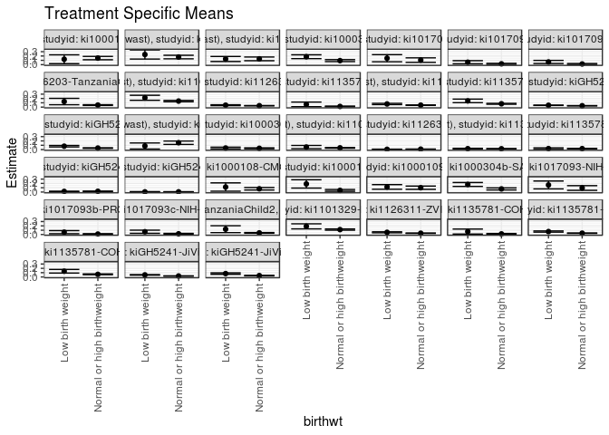

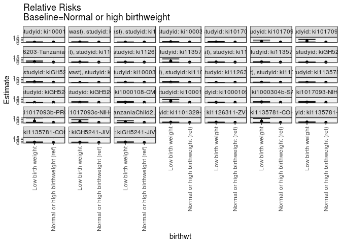

[figure not shown]

[figure not shown]

## Results Table

### Parameter: TSM

| agecat | studyid | country | intervention_level | baseline_level | estimate | ci_lower | ci_upper |
| --- | --- | --- | --- | --- | --- | --- | --- |
| 0-24 months (no birth wast) | ki1000108-CMC-V-BCS-2002 | INDIA | Normal or high birthweight | NA | 0.1524390 | 0.1134865 | 0.1913915 |
| 0-24 months (no birth wast) | ki1000108-CMC-V-BCS-2002 | INDIA | Low birth weight | NA | 0.1250000 | 0.0223715 | 0.2276285 |
| 0-24 months (no birth wast) | ki1000108-IRC | INDIA | Normal or high birthweight | NA | 0.1759692 | 0.1352494 | 0.2166891 |
| 0-24 months (no birth wast) | ki1000108-IRC | INDIA | Low birth weight | NA | 0.2346408 | 0.1290453 | 0.3402364 |
| 0-24 months (no birth wast) | ki1000109-EE | PAKISTAN | Normal or high birthweight | NA | 0.1339110 | 0.0907921 | 0.1770300 |
| 0-24 months (no birth wast) | ki1000109-EE | PAKISTAN | Low birth weight | NA | 0.1311739 | 0.0728064 | 0.1895414 |
| 0-24 months (no birth wast) | ki1000304b-SAS-CompFeed | INDIA | Normal or high birthweight | NA | 0.0933467 | 0.0703683 | 0.1163252 |
| 0-24 months (no birth wast) | ki1000304b-SAS-CompFeed | INDIA | Low birth weight | NA | 0.1836656 | 0.1394396 | 0.2278917 |
| 0-24 months (no birth wast) | ki1017093-NIH-Birth | BANGLADESH | Normal or high birthweight | NA | 0.1060327 | 0.0542836 | 0.1577818 |
| 0-24 months (no birth wast) | ki1017093-NIH-Birth | BANGLADESH | Low birth weight | NA | 0.1488588 | 0.0662325 | 0.2314851 |
| 0-24 months (no birth wast) | ki1017093b-PROVIDE | BANGLADESH | Normal or high birthweight | NA | 0.0189394 | 0.0073041 | 0.0305747 |
| 0-24 months (no birth wast) | ki1017093b-PROVIDE | BANGLADESH | Low birth weight | NA | 0.0566038 | 0.0206590 | 0.0925485 |
| 0-24 months (no birth wast) | ki1017093c-NIH-Crypto | BANGLADESH | Normal or high birthweight | NA | 0.0155440 | 0.0054613 | 0.0256267 |
| 0-24 months (no birth wast) | ki1017093c-NIH-Crypto | BANGLADESH | Low birth weight | NA | 0.0628571 | 0.0268741 | 0.0988402 |
| 0-24 months (no birth wast) | ki1066203-TanzaniaChild2 | TANZANIA, UNITED REPUBLIC OF | Normal or high birthweight | NA | 0.0473952 | 0.0386695 | 0.0561210 |
| 0-24 months (no birth wast) | ki1066203-TanzaniaChild2 | TANZANIA, UNITED REPUBLIC OF | Low birth weight | NA | 0.1289862 | 0.0550516 | 0.2029207 |
| 0-24 months (no birth wast) | ki1101329-Keneba | GAMBIA | Normal or high birthweight | NA | 0.1398025 | 0.1242275 | 0.1553775 |
| 0-24 months (no birth wast) | ki1101329-Keneba | GAMBIA | Low birth weight | NA | 0.2160610 | 0.1580104 | 0.2741117 |
| 0-24 months (no birth wast) | ki1126311-ZVITAMBO | ZIMBABWE | Normal or high birthweight | NA | 0.0329517 | 0.0297411 | 0.0361623 |
| 0-24 months (no birth wast) | ki1126311-ZVITAMBO | ZIMBABWE | Low birth weight | NA | 0.0451054 | 0.0349772 | 0.0552335 |
| 0-24 months (no birth wast) | ki1135781-COHORTS | GUATEMALA | Normal or high birthweight | NA | 0.0155131 | 0.0071413 | 0.0238849 |
| 0-24 months (no birth wast) | ki1135781-COHORTS | GUATEMALA | Low birth weight | NA | 0.0632911 | 0.0095700 | 0.1170123 |
| 0-24 months (no birth wast) | ki1135781-COHORTS | INDIA | Normal or high birthweight | NA | 0.0454329 | 0.0398297 | 0.0510361 |
| 0-24 months (no birth wast) | ki1135781-COHORTS | INDIA | Low birth weight | NA | 0.0730106 | 0.0584127 | 0.0876085 |
| 0-24 months (no birth wast) | ki1135781-COHORTS | PHILIPPINES | Normal or high birthweight | NA | 0.0772281 | 0.0671543 | 0.0873020 |
| 0-24 months (no birth wast) | ki1135781-COHORTS | PHILIPPINES | Low birth weight | NA | 0.1438929 | 0.1026900 | 0.1850959 |
| 0-24 months (no birth wast) | kiGH5241-JiVitA-3 | BANGLADESH | Normal or high birthweight | NA | 0.0316487 | 0.0285758 | 0.0347216 |
| 0-24 months (no birth wast) | kiGH5241-JiVitA-3 | BANGLADESH | Low birth weight | NA | 0.0426534 | 0.0381953 | 0.0471116 |
| 0-24 months (no birth wast) | kiGH5241-JiVitA-4 | BANGLADESH | Normal or high birthweight | NA | 0.0353050 | 0.0284496 | 0.0421605 |
| 0-24 months (no birth wast) | kiGH5241-JiVitA-4 | BANGLADESH | Low birth weight | NA | 0.0783247 | 0.0614177 | 0.0952317 |
| 0-6 months (no birth wast) | ki1000108-IRC | INDIA | Normal or high birthweight | NA | 0.1585366 | 0.1189586 | 0.1981146 |
| 0-6 months (no birth wast) | ki1000108-IRC | INDIA | Low birth weight | NA | 0.0833333 | 0.0133092 | 0.1533575 |
| 0-6 months (no birth wast) | ki1000304b-SAS-CompFeed | INDIA | Normal or high birthweight | NA | 0.0296046 | 0.0183968 | 0.0408124 |
| 0-6 months (no birth wast) | ki1000304b-SAS-CompFeed | INDIA | Low birth weight | NA | 0.0365242 | 0.0164942 | 0.0565542 |
| 0-6 months (no birth wast) | ki1101329-Keneba | GAMBIA | Normal or high birthweight | NA | 0.0404500 | 0.0312089 | 0.0496911 |
| 0-6 months (no birth wast) | ki1101329-Keneba | GAMBIA | Low birth weight | NA | 0.0583960 | 0.0212202 | 0.0955718 |
| 0-6 months (no birth wast) | ki1126311-ZVITAMBO | ZIMBABWE | Normal or high birthweight | NA | 0.0102586 | 0.0084377 | 0.0120795 |
| 0-6 months (no birth wast) | ki1126311-ZVITAMBO | ZIMBABWE | Low birth weight | NA | 0.0064506 | 0.0022883 | 0.0106130 |
| 0-6 months (no birth wast) | ki1135781-COHORTS | INDIA | Normal or high birthweight | NA | 0.0189373 | 0.0151778 | 0.0226968 |
| 0-6 months (no birth wast) | ki1135781-COHORTS | INDIA | Low birth weight | NA | 0.0209278 | 0.0121394 | 0.0297161 |
| 0-6 months (no birth wast) | ki1135781-COHORTS | PHILIPPINES | Normal or high birthweight | NA | 0.0222965 | 0.0167171 | 0.0278759 |
| 0-6 months (no birth wast) | ki1135781-COHORTS | PHILIPPINES | Low birth weight | NA | 0.0228137 | 0.0047656 | 0.0408617 |
| 0-6 months (no birth wast) | kiGH5241-JiVitA-3 | BANGLADESH | Normal or high birthweight | NA | 0.0175695 | 0.0152569 | 0.0198822 |
| 0-6 months (no birth wast) | kiGH5241-JiVitA-3 | BANGLADESH | Low birth weight | NA | 0.0146940 | 0.0120125 | 0.0173754 |
| 0-6 months (no birth wast) | kiGH5241-JiVitA-4 | BANGLADESH | Normal or high birthweight | NA | 0.0048691 | 0.0015684 | 0.0081699 |
| 0-6 months (no birth wast) | kiGH5241-JiVitA-4 | BANGLADESH | Low birth weight | NA | 0.0046041 | -0.0002959 | 0.0095040 |
| 6-24 months | ki1000108-CMC-V-BCS-2002 | INDIA | Normal or high birthweight | NA | 0.0757576 | 0.0471698 | 0.1043453 |
| 6-24 months | ki1000108-CMC-V-BCS-2002 | INDIA | Low birth weight | NA | 0.1162791 | 0.0203379 | 0.2122203 |
| 6-24 months | ki1000108-IRC | INDIA | Normal or high birthweight | NA | 0.0383735 | 0.0179226 | 0.0588243 |
| 6-24 months | ki1000108-IRC | INDIA | Low birth weight | NA | 0.1881478 | 0.0919227 | 0.2843730 |
| 6-24 months | ki1000109-EE | PAKISTAN | Normal or high birthweight | NA | 0.1002867 | 0.0626170 | 0.1379564 |
| 6-24 months | ki1000109-EE | PAKISTAN | Low birth weight | NA | 0.1180892 | 0.0643007 | 0.1718777 |
| 6-24 months | ki1000304b-SAS-CompFeed | INDIA | Normal or high birthweight | NA | 0.0728270 | 0.0488762 | 0.0967778 |
| 6-24 months | ki1000304b-SAS-CompFeed | INDIA | Low birth weight | NA | 0.1752604 | 0.1300939 | 0.2204270 |
| 6-24 months | ki1017093-NIH-Birth | BANGLADESH | Normal or high birthweight | NA | 0.0939002 | 0.0400634 | 0.1477371 |
| 6-24 months | ki1017093-NIH-Birth | BANGLADESH | Low birth weight | NA | 0.1640458 | 0.0726765 | 0.2554151 |
| 6-24 months | ki1017093b-PROVIDE | BANGLADESH | Normal or high birthweight | NA | 0.0107066 | 0.0013648 | 0.0200485 |
| 6-24 months | ki1017093b-PROVIDE | BANGLADESH | Low birth weight | NA | 0.0540541 | 0.0175940 | 0.0905142 |
| 6-24 months | ki1017093c-NIH-Crypto | BANGLADESH | Normal or high birthweight | NA | 0.0161002 | 0.0056595 | 0.0265409 |
| 6-24 months | ki1017093c-NIH-Crypto | BANGLADESH | Low birth weight | NA | 0.0643275 | 0.0275309 | 0.1011241 |
| 6-24 months | ki1066203-TanzaniaChild2 | TANZANIA, UNITED REPUBLIC OF | Normal or high birthweight | NA | 0.0377651 | 0.0292650 | 0.0462653 |
| 6-24 months | ki1066203-TanzaniaChild2 | TANZANIA, UNITED REPUBLIC OF | Low birth weight | NA | 0.1230769 | 0.0431912 | 0.2029626 |
| 6-24 months | ki1101329-Keneba | GAMBIA | Normal or high birthweight | NA | 0.1135314 | 0.0990782 | 0.1279846 |
| 6-24 months | ki1101329-Keneba | GAMBIA | Low birth weight | NA | 0.1891512 | 0.1303137 | 0.2479886 |
| 6-24 months | ki1126311-ZVITAMBO | ZIMBABWE | Normal or high birthweight | NA | 0.0297387 | 0.0262793 | 0.0331981 |
| 6-24 months | ki1126311-ZVITAMBO | ZIMBABWE | Low birth weight | NA | 0.0510651 | 0.0394949 | 0.0626353 |
| 6-24 months | ki1135781-COHORTS | GUATEMALA | Normal or high birthweight | NA | 0.0145889 | 0.0060255 | 0.0231522 |
| 6-24 months | ki1135781-COHORTS | GUATEMALA | Low birth weight | NA | 0.0684932 | 0.0105148 | 0.1264715 |
| 6-24 months | ki1135781-COHORTS | INDIA | Normal or high birthweight | NA | 0.0308485 | 0.0260643 | 0.0356327 |
| 6-24 months | ki1135781-COHORTS | INDIA | Low birth weight | NA | 0.0684203 | 0.0546689 | 0.0821717 |
| 6-24 months | ki1135781-COHORTS | PHILIPPINES | Normal or high birthweight | NA | 0.0612909 | 0.0518948 | 0.0706869 |
| 6-24 months | ki1135781-COHORTS | PHILIPPINES | Low birth weight | NA | 0.1328717 | 0.0910931 | 0.1746503 |
| 6-24 months | kiGH5241-JiVitA-3 | BANGLADESH | Normal or high birthweight | NA | 0.0228153 | 0.0196932 | 0.0259375 |
| 6-24 months | kiGH5241-JiVitA-3 | BANGLADESH | Low birth weight | NA | 0.0484709 | 0.0425352 | 0.0544065 |
| 6-24 months | kiGH5241-JiVitA-4 | BANGLADESH | Normal or high birthweight | NA | 0.0320961 | 0.0254705 | 0.0387218 |
| 6-24 months | kiGH5241-JiVitA-4 | BANGLADESH | Low birth weight | NA | 0.0786411 | 0.0615048 | 0.0957773 |

### Parameter: E(Y)

| agecat | studyid | country | intervention_level | baseline_level | estimate | ci_lower | ci_upper |
| --- | --- | --- | --- | --- | --- | --- | --- |
| 0-24 months (no birth wast) | ki1000108-CMC-V-BCS-2002 | INDIA | NA | NA | 0.1494565 | 0.1129794 | 0.1859337 |
| 0-24 months (no birth wast) | ki1000108-IRC | INDIA | NA | NA | 0.1891892 | 0.1510920 | 0.2272864 |
| 0-24 months (no birth wast) | ki1000109-EE | PAKISTAN | NA | NA | 0.1352785 | 0.1007079 | 0.1698491 |
| 0-24 months (no birth wast) | ki1000304b-SAS-CompFeed | INDIA | NA | NA | 0.1146113 | 0.0915227 | 0.1376999 |
| 0-24 months (no birth wast) | ki1017093-NIH-Birth | BANGLADESH | NA | NA | 0.1209302 | 0.0772464 | 0.1646140 |
| 0-24 months (no birth wast) | ki1017093b-PROVIDE | BANGLADESH | NA | NA | 0.0276565 | 0.0153851 | 0.0399279 |
| 0-24 months (no birth wast) | ki1017093c-NIH-Crypto | BANGLADESH | NA | NA | 0.0265252 | 0.0150478 | 0.0380026 |
| 0-24 months (no birth wast) | ki1066203-TanzaniaChild2 | TANZANIA, UNITED REPUBLIC OF | NA | NA | 0.0500212 | 0.0412227 | 0.0588197 |
| 0-24 months (no birth wast) | ki1101329-Keneba | GAMBIA | NA | NA | 0.1458432 | 0.1307620 | 0.1609245 |
| 0-24 months (no birth wast) | ki1126311-ZVITAMBO | ZIMBABWE | NA | NA | 0.0344624 | 0.0313943 | 0.0375306 |
| 0-24 months (no birth wast) | ki1135781-COHORTS | GUATEMALA | NA | NA | 0.0196292 | 0.0106457 | 0.0286128 |
| 0-24 months (no birth wast) | ki1135781-COHORTS | INDIA | NA | NA | 0.0505825 | 0.0452644 | 0.0559005 |
| 0-24 months (no birth wast) | ki1135781-COHORTS | PHILIPPINES | NA | NA | 0.0833613 | 0.0734265 | 0.0932961 |
| 0-24 months (no birth wast) | kiGH5241-JiVitA-3 | BANGLADESH | NA | NA | 0.0357927 | 0.0332035 | 0.0383818 |
| 0-24 months (no birth wast) | kiGH5241-JiVitA-4 | BANGLADESH | NA | NA | 0.0463561 | 0.0396916 | 0.0530207 |
| 0-6 months (no birth wast) | ki1000108-IRC | INDIA | NA | NA | 0.1469072 | 0.1116367 | 0.1821778 |
| 0-6 months (no birth wast) | ki1000304b-SAS-CompFeed | INDIA | NA | NA | 0.0313993 | 0.0187576 | 0.0440411 |
| 0-6 months (no birth wast) | ki1101329-Keneba | GAMBIA | NA | NA | 0.0419255 | 0.0329863 | 0.0508646 |
| 0-6 months (no birth wast) | ki1126311-ZVITAMBO | ZIMBABWE | NA | NA | 0.0098334 | 0.0081577 | 0.0115090 |
| 0-6 months (no birth wast) | ki1135781-COHORTS | INDIA | NA | NA | 0.0193293 | 0.0158606 | 0.0227980 |
| 0-6 months (no birth wast) | ki1135781-COHORTS | PHILIPPINES | NA | NA | 0.0223426 | 0.0170120 | 0.0276732 |
| 0-6 months (no birth wast) | kiGH5241-JiVitA-3 | BANGLADESH | NA | NA | 0.0165737 | 0.0147559 | 0.0183915 |
| 0-6 months (no birth wast) | kiGH5241-JiVitA-4 | BANGLADESH | NA | NA | 0.0048033 | 0.0020515 | 0.0075551 |
| 6-24 months | ki1000108-CMC-V-BCS-2002 | INDIA | NA | NA | 0.0804290 | 0.0527929 | 0.1080650 |
| 6-24 months | ki1000108-IRC | INDIA | NA | NA | 0.0637255 | 0.0399949 | 0.0874561 |
| 6-24 months | ki1000109-EE | PAKISTAN | NA | NA | 0.1040000 | 0.0730627 | 0.1349373 |
| 6-24 months | ki1000304b-SAS-CompFeed | INDIA | NA | NA | 0.0964467 | 0.0724546 | 0.1204388 |
| 6-24 months | ki1017093-NIH-Birth | BANGLADESH | NA | NA | 0.1166667 | 0.0696386 | 0.1636948 |
| 6-24 months | ki1017093b-PROVIDE | BANGLADESH | NA | NA | 0.0211382 | 0.0097604 | 0.0325160 |
| 6-24 months | ki1017093c-NIH-Crypto | BANGLADESH | NA | NA | 0.0273973 | 0.0155476 | 0.0392469 |
| 6-24 months | ki1066203-TanzaniaChild2 | TANZANIA, UNITED REPUBLIC OF | NA | NA | 0.0405405 | 0.0318905 | 0.0491906 |
| 6-24 months | ki1101329-Keneba | GAMBIA | NA | NA | 0.1196078 | 0.1055228 | 0.1336929 |
| 6-24 months | ki1126311-ZVITAMBO | ZIMBABWE | NA | NA | 0.0325546 | 0.0291854 | 0.0359239 |
| 6-24 months | ki1135781-COHORTS | GUATEMALA | NA | NA | 0.0193470 | 0.0099536 | 0.0287404 |
| 6-24 months | ki1135781-COHORTS | INDIA | NA | NA | 0.0382600 | 0.0335226 | 0.0429975 |
| 6-24 months | ki1135781-COHORTS | PHILIPPINES | NA | NA | 0.0676067 | 0.0582484 | 0.0769649 |
| 6-24 months | kiGH5241-JiVitA-3 | BANGLADESH | NA | NA | 0.0320088 | 0.0291040 | 0.0349136 |
| 6-24 months | kiGH5241-JiVitA-4 | BANGLADESH | NA | NA | 0.0442321 | 0.0375131 | 0.0509510 |

### Parameter: RR

| agecat | studyid | country | intervention_level | baseline_level | estimate | ci_lower | ci_upper |
| --- | --- | --- | --- | --- | --- | --- | --- |
| 0-24 months (no birth wast) | ki1000108-CMC-V-BCS-2002 | INDIA | Normal or high birthweight | Normal or high birthweight | 1.0000000 | 1.0000000 | 1.000000 |
| 0-24 months (no birth wast) | ki1000108-CMC-V-BCS-2002 | INDIA | Low birth weight | Normal or high birthweight | 0.8200000 | 0.3470369 | 1.937546 |
| 0-24 months (no birth wast) | ki1000108-IRC | INDIA | Normal or high birthweight | Normal or high birthweight | 1.0000000 | 1.0000000 | 1.000000 |
| 0-24 months (no birth wast) | ki1000108-IRC | INDIA | Low birth weight | Normal or high birthweight | 1.3334194 | 0.8036909 | 2.212302 |
| 0-24 months (no birth wast) | ki1000109-EE | PAKISTAN | Normal or high birthweight | Normal or high birthweight | 1.0000000 | 1.0000000 | 1.000000 |
| 0-24 months (no birth wast) | ki1000109-EE | PAKISTAN | Low birth weight | Normal or high birthweight | 0.9795600 | 0.5665493 | 1.693653 |
| 0-24 months (no birth wast) | ki1000304b-SAS-CompFeed | INDIA | Normal or high birthweight | Normal or high birthweight | 1.0000000 | 1.0000000 | 1.000000 |
| 0-24 months (no birth wast) | ki1000304b-SAS-CompFeed | INDIA | Low birth weight | Normal or high birthweight | 1.9675635 | 1.4933355 | 2.592389 |
| 0-24 months (no birth wast) | ki1017093-NIH-Birth | BANGLADESH | Normal or high birthweight | Normal or high birthweight | 1.0000000 | 1.0000000 | 1.000000 |
| 0-24 months (no birth wast) | ki1017093-NIH-Birth | BANGLADESH | Low birth weight | Normal or high birthweight | 1.4038957 | 0.6685570 | 2.948025 |
| 0-24 months (no birth wast) | ki1017093b-PROVIDE | BANGLADESH | Normal or high birthweight | Normal or high birthweight | 1.0000000 | 1.0000000 | 1.000000 |
| 0-24 months (no birth wast) | ki1017093b-PROVIDE | BANGLADESH | Low birth weight | Normal or high birthweight | 2.9886792 | 1.2352498 | 7.231091 |
| 0-24 months (no birth wast) | ki1017093c-NIH-Crypto | BANGLADESH | Normal or high birthweight | Normal or high birthweight | 1.0000000 | 1.0000000 | 1.000000 |
| 0-24 months (no birth wast) | ki1017093c-NIH-Crypto | BANGLADESH | Low birth weight | Normal or high birthweight | 4.0438095 | 1.7024219 | 9.605372 |
| 0-24 months (no birth wast) | ki1066203-TanzaniaChild2 | TANZANIA, UNITED REPUBLIC OF | Normal or high birthweight | Normal or high birthweight | 1.0000000 | 1.0000000 | 1.000000 |
| 0-24 months (no birth wast) | ki1066203-TanzaniaChild2 | TANZANIA, UNITED REPUBLIC OF | Low birth weight | Normal or high birthweight | 2.7214995 | 1.4905500 | 4.969011 |
| 0-24 months (no birth wast) | ki1101329-Keneba | GAMBIA | Normal or high birthweight | Normal or high birthweight | 1.0000000 | 1.0000000 | 1.000000 |
| 0-24 months (no birth wast) | ki1101329-Keneba | GAMBIA | Low birth weight | Normal or high birthweight | 1.5454731 | 1.1565337 | 2.065212 |
| 0-24 months (no birth wast) | ki1126311-ZVITAMBO | ZIMBABWE | Normal or high birthweight | Normal or high birthweight | 1.0000000 | 1.0000000 | 1.000000 |
| 0-24 months (no birth wast) | ki1126311-ZVITAMBO | ZIMBABWE | Low birth weight | Normal or high birthweight | 1.3688337 | 1.0716819 | 1.748379 |
| 0-24 months (no birth wast) | ki1135781-COHORTS | GUATEMALA | Normal or high birthweight | Normal or high birthweight | 1.0000000 | 1.0000000 | 1.000000 |
| 0-24 months (no birth wast) | ki1135781-COHORTS | GUATEMALA | Low birth weight | Normal or high birthweight | 4.0798442 | 1.4921752 | 11.154943 |
| 0-24 months (no birth wast) | ki1135781-COHORTS | INDIA | Normal or high birthweight | Normal or high birthweight | 1.0000000 | 1.0000000 | 1.000000 |
| 0-24 months (no birth wast) | ki1135781-COHORTS | INDIA | Low birth weight | Normal or high birthweight | 1.6069990 | 1.2705892 | 2.032479 |
| 0-24 months (no birth wast) | ki1135781-COHORTS | PHILIPPINES | Normal or high birthweight | Normal or high birthweight | 1.0000000 | 1.0000000 | 1.000000 |
| 0-24 months (no birth wast) | ki1135781-COHORTS | PHILIPPINES | Low birth weight | Normal or high birthweight | 1.8632189 | 1.3605536 | 2.551597 |
| 0-24 months (no birth wast) | kiGH5241-JiVitA-3 | BANGLADESH | Normal or high birthweight | Normal or high birthweight | 1.0000000 | 1.0000000 | 1.000000 |
| 0-24 months (no birth wast) | kiGH5241-JiVitA-3 | BANGLADESH | Low birth weight | Normal or high birthweight | 1.3477147 | 1.1714572 | 1.550492 |
| 0-24 months (no birth wast) | kiGH5241-JiVitA-4 | BANGLADESH | Normal or high birthweight | Normal or high birthweight | 1.0000000 | 1.0000000 | 1.000000 |
| 0-24 months (no birth wast) | kiGH5241-JiVitA-4 | BANGLADESH | Low birth weight | Normal or high birthweight | 2.2185143 | 1.6529571 | 2.977576 |
| 0-6 months (no birth wast) | ki1000108-IRC | INDIA | Normal or high birthweight | Normal or high birthweight | 1.0000000 | 1.0000000 | 1.000000 |
| 0-6 months (no birth wast) | ki1000108-IRC | INDIA | Low birth weight | Normal or high birthweight | 0.5256410 | 0.2187716 | 1.262954 |
| 0-6 months (no birth wast) | ki1000304b-SAS-CompFeed | INDIA | Normal or high birthweight | Normal or high birthweight | 1.0000000 | 1.0000000 | 1.000000 |
| 0-6 months (no birth wast) | ki1000304b-SAS-CompFeed | INDIA | Low birth weight | Normal or high birthweight | 1.2337331 | 0.9517239 | 1.599306 |
| 0-6 months (no birth wast) | ki1101329-Keneba | GAMBIA | Normal or high birthweight | Normal or high birthweight | 1.0000000 | 1.0000000 | 1.000000 |
| 0-6 months (no birth wast) | ki1101329-Keneba | GAMBIA | Low birth weight | Normal or high birthweight | 1.4436589 | 0.7343434 | 2.838115 |
| 0-6 months (no birth wast) | ki1126311-ZVITAMBO | ZIMBABWE | Normal or high birthweight | Normal or high birthweight | 1.0000000 | 1.0000000 | 1.000000 |
| 0-6 months (no birth wast) | ki1126311-ZVITAMBO | ZIMBABWE | Low birth weight | Normal or high birthweight | 0.6288019 | 0.3220308 | 1.227807 |
| 0-6 months (no birth wast) | ki1135781-COHORTS | INDIA | Normal or high birthweight | Normal or high birthweight | 1.0000000 | 1.0000000 | 1.000000 |
| 0-6 months (no birth wast) | ki1135781-COHORTS | INDIA | Low birth weight | Normal or high birthweight | 1.1051088 | 0.6945392 | 1.758382 |
| 0-6 months (no birth wast) | ki1135781-COHORTS | PHILIPPINES | Normal or high birthweight | Normal or high birthweight | 1.0000000 | 1.0000000 | 1.000000 |
| 0-6 months (no birth wast) | ki1135781-COHORTS | PHILIPPINES | Low birth weight | Normal or high birthweight | 1.0231939 | 0.4462795 | 2.345897 |
| 0-6 months (no birth wast) | kiGH5241-JiVitA-3 | BANGLADESH | Normal or high birthweight | Normal or high birthweight | 1.0000000 | 1.0000000 | 1.000000 |
| 0-6 months (no birth wast) | kiGH5241-JiVitA-3 | BANGLADESH | Low birth weight | Normal or high birthweight | 0.8363327 | 0.6728660 | 1.039512 |
| 0-6 months (no birth wast) | kiGH5241-JiVitA-4 | BANGLADESH | Normal or high birthweight | Normal or high birthweight | 1.0000000 | 1.0000000 | 1.000000 |
| 0-6 months (no birth wast) | kiGH5241-JiVitA-4 | BANGLADESH | Low birth weight | Normal or high birthweight | 0.9455571 | 0.2661084 | 3.359828 |
| 6-24 months | ki1000108-CMC-V-BCS-2002 | INDIA | Normal or high birthweight | Normal or high birthweight | 1.0000000 | 1.0000000 | 1.000000 |
| 6-24 months | ki1000108-CMC-V-BCS-2002 | INDIA | Low birth weight | Normal or high birthweight | 1.5348837 | 0.6195028 | 3.802837 |
| 6-24 months | ki1000108-IRC | INDIA | Normal or high birthweight | Normal or high birthweight | 1.0000000 | 1.0000000 | 1.000000 |
| 6-24 months | ki1000108-IRC | INDIA | Low birth weight | Normal or high birthweight | 4.9030697 | 2.3370421 | 10.286547 |
| 6-24 months | ki1000109-EE | PAKISTAN | Normal or high birthweight | Normal or high birthweight | 1.0000000 | 1.0000000 | 1.000000 |
| 6-24 months | ki1000109-EE | PAKISTAN | Low birth weight | Normal or high birthweight | 1.1775160 | 0.6544021 | 2.118795 |
| 6-24 months | ki1000304b-SAS-CompFeed | INDIA | Normal or high birthweight | Normal or high birthweight | 1.0000000 | 1.0000000 | 1.000000 |
| 6-24 months | ki1000304b-SAS-CompFeed | INDIA | Low birth weight | Normal or high birthweight | 2.4065308 | 1.6545036 | 3.500379 |
| 6-24 months | ki1017093-NIH-Birth | BANGLADESH | Normal or high birthweight | Normal or high birthweight | 1.0000000 | 1.0000000 | 1.000000 |
| 6-24 months | ki1017093-NIH-Birth | BANGLADESH | Low birth weight | Normal or high birthweight | 1.7470228 | 0.7849118 | 3.888448 |
| 6-24 months | ki1017093b-PROVIDE | BANGLADESH | Normal or high birthweight | Normal or high birthweight | 1.0000000 | 1.0000000 | 1.000000 |
| 6-24 months | ki1017093b-PROVIDE | BANGLADESH | Low birth weight | Normal or high birthweight | 5.0486486 | 1.6757724 | 15.210211 |
| 6-24 months | ki1017093c-NIH-Crypto | BANGLADESH | Normal or high birthweight | Normal or high birthweight | 1.0000000 | 1.0000000 | 1.000000 |
| 6-24 months | ki1017093c-NIH-Crypto | BANGLADESH | Low birth weight | Normal or high birthweight | 3.9954516 | 1.6827630 | 9.486561 |
| 6-24 months | ki1066203-TanzaniaChild2 | TANZANIA, UNITED REPUBLIC OF | Normal or high birthweight | Normal or high birthweight | 1.0000000 | 1.0000000 | 1.000000 |
| 6-24 months | ki1066203-TanzaniaChild2 | TANZANIA, UNITED REPUBLIC OF | Low birth weight | Normal or high birthweight | 3.2590095 | 1.6395696 | 6.478007 |
| 6-24 months | ki1101329-Keneba | GAMBIA | Normal or high birthweight | Normal or high birthweight | 1.0000000 | 1.0000000 | 1.000000 |
| 6-24 months | ki1101329-Keneba | GAMBIA | Low birth weight | Normal or high birthweight | 1.6660691 | 1.1908359 | 2.330956 |
| 6-24 months | ki1126311-ZVITAMBO | ZIMBABWE | Normal or high birthweight | Normal or high birthweight | 1.0000000 | 1.0000000 | 1.000000 |
| 6-24 months | ki1126311-ZVITAMBO | ZIMBABWE | Low birth weight | Normal or high birthweight | 1.7171287 | 1.3310534 | 2.215186 |
| 6-24 months | ki1135781-COHORTS | GUATEMALA | Normal or high birthweight | Normal or high birthweight | 1.0000000 | 1.0000000 | 1.000000 |
| 6-24 months | ki1135781-COHORTS | GUATEMALA | Low birth weight | Normal or high birthweight | 4.6948941 | 1.6759628 | 13.151862 |
| 6-24 months | ki1135781-COHORTS | INDIA | Normal or high birthweight | Normal or high birthweight | 1.0000000 | 1.0000000 | 1.000000 |
| 6-24 months | ki1135781-COHORTS | INDIA | Low birth weight | Normal or high birthweight | 2.2179483 | 1.7208405 | 2.858658 |
| 6-24 months | ki1135781-COHORTS | PHILIPPINES | Normal or high birthweight | Normal or high birthweight | 1.0000000 | 1.0000000 | 1.000000 |
| 6-24 months | ki1135781-COHORTS | PHILIPPINES | Low birth weight | Normal or high birthweight | 2.1678884 | 1.5285798 | 3.074580 |
| 6-24 months | kiGH5241-JiVitA-3 | BANGLADESH | Normal or high birthweight | Normal or high birthweight | 1.0000000 | 1.0000000 | 1.000000 |
| 6-24 months | kiGH5241-JiVitA-3 | BANGLADESH | Low birth weight | Normal or high birthweight | 2.1244854 | 1.7650564 | 2.557107 |
| 6-24 months | kiGH5241-JiVitA-4 | BANGLADESH | Normal or high birthweight | Normal or high birthweight | 1.0000000 | 1.0000000 | 1.000000 |
| 6-24 months | kiGH5241-JiVitA-4 | BANGLADESH | Low birth weight | Normal or high birthweight | 2.4501718 | 1.8149634 | 3.307693 |

### Parameter: PAR

| agecat | studyid | country | intervention_level | baseline_level | estimate | ci_lower | ci_upper |
| --- | --- | --- | --- | --- | --- | --- | --- |
| 0-24 months (no birth wast) | ki1000108-CMC-V-BCS-2002 | INDIA | Normal or high birthweight | NA | -0.0029825 | -0.0149462 | 0.0089812 |
| 0-24 months (no birth wast) | ki1000108-IRC | INDIA | Normal or high birthweight | NA | 0.0132199 | -0.0055938 | 0.0320337 |
| 0-24 months (no birth wast) | ki1000109-EE | PAKISTAN | Normal or high birthweight | NA | 0.0013675 | -0.0241078 | 0.0268428 |
| 0-24 months (no birth wast) | ki1000304b-SAS-CompFeed | INDIA | Normal or high birthweight | NA | 0.0212645 | 0.0119767 | 0.0305523 |
| 0-24 months (no birth wast) | ki1017093-NIH-Birth | BANGLADESH | Normal or high birthweight | NA | 0.0148976 | -0.0190004 | 0.0487956 |
| 0-24 months (no birth wast) | ki1017093b-PROVIDE | BANGLADESH | Normal or high birthweight | NA | 0.0087171 | -0.0001074 | 0.0175416 |
| 0-24 months (no birth wast) | ki1017093c-NIH-Crypto | BANGLADESH | Normal or high birthweight | NA | 0.0109812 | 0.0021914 | 0.0197709 |
| 0-24 months (no birth wast) | ki1066203-TanzaniaChild2 | TANZANIA, UNITED REPUBLIC OF | Normal or high birthweight | NA | 0.0026259 | 0.0000852 | 0.0051667 |
| 0-24 months (no birth wast) | ki1101329-Keneba | GAMBIA | Normal or high birthweight | NA | 0.0060407 | 0.0007216 | 0.0113598 |
| 0-24 months (no birth wast) | ki1126311-ZVITAMBO | ZIMBABWE | Normal or high birthweight | NA | 0.0015108 | 0.0002215 | 0.0028000 |
| 0-24 months (no birth wast) | ki1135781-COHORTS | GUATEMALA | Normal or high birthweight | NA | 0.0041161 | -0.0006476 | 0.0088798 |
| 0-24 months (no birth wast) | ki1135781-COHORTS | INDIA | Normal or high birthweight | NA | 0.0051496 | 0.0022482 | 0.0080509 |
| 0-24 months (no birth wast) | ki1135781-COHORTS | PHILIPPINES | Normal or high birthweight | NA | 0.0061332 | 0.0022039 | 0.0100625 |
| 0-24 months (no birth wast) | kiGH5241-JiVitA-3 | BANGLADESH | Normal or high birthweight | NA | 0.0041439 | 0.0021710 | 0.0061169 |
| 0-24 months (no birth wast) | kiGH5241-JiVitA-4 | BANGLADESH | Normal or high birthweight | NA | 0.0110511 | 0.0062509 | 0.0158514 |
| 0-6 months (no birth wast) | ki1000108-IRC | INDIA | Normal or high birthweight | NA | -0.0116294 | -0.0243594 | 0.0011006 |
| 0-6 months (no birth wast) | ki1000304b-SAS-CompFeed | INDIA | Normal or high birthweight | NA | 0.0017947 | -0.0005712 | 0.0041606 |
| 0-6 months (no birth wast) | ki1101329-Keneba | GAMBIA | Normal or high birthweight | NA | 0.0014755 | -0.0017532 | 0.0047041 |
| 0-6 months (no birth wast) | ki1126311-ZVITAMBO | ZIMBABWE | Normal or high birthweight | NA | -0.0004253 | -0.0009350 | 0.0000845 |
| 0-6 months (no birth wast) | ki1135781-COHORTS | INDIA | Normal or high birthweight | NA | 0.0003920 | -0.0012024 | 0.0019864 |
| 0-6 months (no birth wast) | ki1135781-COHORTS | PHILIPPINES | Normal or high birthweight | NA | 0.0000460 | -0.0016358 | 0.0017279 |
| 0-6 months (no birth wast) | kiGH5241-JiVitA-3 | BANGLADESH | Normal or high birthweight | NA | -0.0009958 | -0.0022549 | 0.0002633 |
| 0-6 months (no birth wast) | kiGH5241-JiVitA-4 | BANGLADESH | Normal or high birthweight | NA | -0.0000658 | -0.0015406 | 0.0014089 |
| 6-24 months | ki1000108-CMC-V-BCS-2002 | INDIA | Normal or high birthweight | NA | 0.0046714 | -0.0069441 | 0.0162869 |
| 6-24 months | ki1000108-IRC | INDIA | Normal or high birthweight | NA | 0.0253520 | 0.0083739 | 0.0423301 |
| 6-24 months | ki1000109-EE | PAKISTAN | Normal or high birthweight | NA | 0.0037133 | -0.0193204 | 0.0267471 |
| 6-24 months | ki1000304b-SAS-CompFeed | INDIA | Normal or high birthweight | NA | 0.0236197 | 0.0128862 | 0.0343532 |
| 6-24 months | ki1017093-NIH-Birth | BANGLADESH | Normal or high birthweight | NA | 0.0227664 | -0.0146478 | 0.0601807 |
| 6-24 months | ki1017093b-PROVIDE | BANGLADESH | Normal or high birthweight | NA | 0.0104316 | 0.0012562 | 0.0196070 |
| 6-24 months | ki1017093c-NIH-Crypto | BANGLADESH | Normal or high birthweight | NA | 0.0112971 | 0.0022155 | 0.0203787 |
| 6-24 months | ki1066203-TanzaniaChild2 | TANZANIA, UNITED REPUBLIC OF | Normal or high birthweight | NA | 0.0027754 | 0.0000789 | 0.0054719 |
| 6-24 months | ki1101329-Keneba | GAMBIA | Normal or high birthweight | NA | 0.0060764 | 0.0009368 | 0.0112161 |
| 6-24 months | ki1126311-ZVITAMBO | ZIMBABWE | Normal or high birthweight | NA | 0.0028160 | 0.0012471 | 0.0043848 |
| 6-24 months | ki1135781-COHORTS | GUATEMALA | Normal or high birthweight | NA | 0.0047582 | -0.0005192 | 0.0100356 |
| 6-24 months | ki1135781-COHORTS | INDIA | Normal or high birthweight | NA | 0.0074116 | 0.0044776 | 0.0103456 |
| 6-24 months | ki1135781-COHORTS | PHILIPPINES | Normal or high birthweight | NA | 0.0063158 | 0.0024147 | 0.0102169 |
| 6-24 months | kiGH5241-JiVitA-3 | BANGLADESH | Normal or high birthweight | NA | 0.0091935 | 0.0067457 | 0.0116412 |
| 6-24 months | kiGH5241-JiVitA-4 | BANGLADESH | Normal or high birthweight | NA | 0.0121359 | 0.0072959 | 0.0169759 |

### Parameter: PAF

| agecat | studyid | country | intervention_level | baseline_level | estimate | ci_lower | ci_upper |
| --- | --- | --- | --- | --- | --- | --- | --- |
| 0-24 months (no birth wast) | ki1000108-CMC-V-BCS-2002 | INDIA | Normal or high birthweight | NA | -0.0199557 | -0.1031258 | 0.0569439 |
| 0-24 months (no birth wast) | ki1000108-IRC | INDIA | Normal or high birthweight | NA | 0.0698768 | -0.0345763 | 0.1637841 |
| 0-24 months (no birth wast) | ki1000109-EE | PAKISTAN | Normal or high birthweight | NA | 0.0101088 | -0.1973614 | 0.1816302 |
| 0-24 months (no birth wast) | ki1000304b-SAS-CompFeed | INDIA | Normal or high birthweight | NA | 0.1855360 | 0.0996041 | 0.2632668 |
| 0-24 months (no birth wast) | ki1017093-NIH-Birth | BANGLADESH | Normal or high birthweight | NA | 0.1231913 | -0.2041151 | 0.3615283 |
| 0-24 months (no birth wast) | ki1017093b-PROVIDE | BANGLADESH | Normal or high birthweight | NA | 0.3151914 | -0.0430123 | 0.5503765 |
| 0-24 months (no birth wast) | ki1017093c-NIH-Crypto | BANGLADESH | Normal or high birthweight | NA | 0.4139896 | 0.0540478 | 0.6369709 |
| 0-24 months (no birth wast) | ki1066203-TanzaniaChild2 | TANZANIA, UNITED REPUBLIC OF | Normal or high birthweight | NA | 0.0524967 | 0.0011220 | 0.1012290 |
| 0-24 months (no birth wast) | ki1101329-Keneba | GAMBIA | Normal or high birthweight | NA | 0.0414192 | 0.0043489 | 0.0771093 |
| 0-24 months (no birth wast) | ki1126311-ZVITAMBO | ZIMBABWE | Normal or high birthweight | NA | 0.0438379 | 0.0058682 | 0.0803574 |
| 0-24 months (no birth wast) | ki1135781-COHORTS | GUATEMALA | Normal or high birthweight | NA | 0.2096924 | -0.0486896 | 0.4044128 |
| 0-24 months (no birth wast) | ki1135781-COHORTS | INDIA | Normal or high birthweight | NA | 0.1018054 | 0.0434777 | 0.1565763 |
| 0-24 months (no birth wast) | ki1135781-COHORTS | PHILIPPINES | Normal or high birthweight | NA | 0.0735736 | 0.0258600 | 0.1189503 |
| 0-24 months (no birth wast) | kiGH5241-JiVitA-3 | BANGLADESH | Normal or high birthweight | NA | 0.1157765 | 0.0592316 | 0.1689228 |
| 0-24 months (no birth wast) | kiGH5241-JiVitA-4 | BANGLADESH | Normal or high birthweight | NA | 0.2383956 | 0.1336738 | 0.3304586 |
| 0-6 months (no birth wast) | ki1000108-IRC | INDIA | Normal or high birthweight | NA | -0.0791613 | -0.1679596 | 0.0028857 |
| 0-6 months (no birth wast) | ki1000304b-SAS-CompFeed | INDIA | Normal or high birthweight | NA | 0.0571575 | -0.0074055 | 0.1175829 |
| 0-6 months (no birth wast) | ki1101329-Keneba | GAMBIA | Normal or high birthweight | NA | 0.0351925 | -0.0446750 | 0.1089540 |
| 0-6 months (no birth wast) | ki1126311-ZVITAMBO | ZIMBABWE | Normal or high birthweight | NA | -0.0432481 | -0.0958176 | 0.0067994 |
| 0-6 months (no birth wast) | ki1135781-COHORTS | INDIA | Normal or high birthweight | NA | 0.0202777 | -0.0657105 | 0.0993278 |
| 0-6 months (no birth wast) | ki1135781-COHORTS | PHILIPPINES | Normal or high birthweight | NA | 0.0020607 | -0.0761268 | 0.0745675 |
| 0-6 months (no birth wast) | kiGH5241-JiVitA-3 | BANGLADESH | Normal or high birthweight | NA | -0.0600829 | -0.1384352 | 0.0128768 |
| 0-6 months (no birth wast) | kiGH5241-JiVitA-4 | BANGLADESH | Normal or high birthweight | NA | -0.0137090 | -0.3709271 | 0.2504300 |
| 6-24 months | ki1000108-CMC-V-BCS-2002 | INDIA | Normal or high birthweight | NA | 0.0580808 | -0.0966511 | 0.1909808 |
| 6-24 months | ki1000108-IRC | INDIA | Normal or high birthweight | NA | 0.3978316 | 0.1254504 | 0.5853788 |
| 6-24 months | ki1000109-EE | PAKISTAN | Normal or high birthweight | NA | 0.0357050 | -0.2129487 | 0.2333848 |
| 6-24 months | ki1000304b-SAS-CompFeed | INDIA | Normal or high birthweight | NA | 0.2448990 | 0.1217649 | 0.3507689 |
| 6-24 months | ki1017093-NIH-Birth | BANGLADESH | Normal or high birthweight | NA | 0.1951410 | -0.1894172 | 0.4553652 |
| 6-24 months | ki1017093b-PROVIDE | BANGLADESH | Normal or high birthweight | NA | 0.4934937 | -0.0019911 | 0.7439611 |
| 6-24 months | ki1017093c-NIH-Crypto | BANGLADESH | Normal or high birthweight | NA | 0.4123435 | 0.0515703 | 0.6358821 |
| 6-24 months | ki1066203-TanzaniaChild2 | TANZANIA, UNITED REPUBLIC OF | Normal or high birthweight | NA | 0.0684601 | 0.0011170 | 0.1312630 |
| 6-24 months | ki1101329-Keneba | GAMBIA | Normal or high birthweight | NA | 0.0508029 | 0.0070975 | 0.0925845 |
| 6-24 months | ki1126311-ZVITAMBO | ZIMBABWE | Normal or high birthweight | NA | 0.0864997 | 0.0377914 | 0.1327424 |
| 6-24 months | ki1135781-COHORTS | GUATEMALA | Normal or high birthweight | NA | 0.2459383 | -0.0450901 | 0.4559235 |
| 6-24 months | ki1135781-COHORTS | INDIA | Normal or high birthweight | NA | 0.1937153 | 0.1169585 | 0.2638002 |
| 6-24 months | ki1135781-COHORTS | PHILIPPINES | Normal or high birthweight | NA | 0.0934198 | 0.0350471 | 0.1482613 |
| 6-24 months | kiGH5241-JiVitA-3 | BANGLADESH | Normal or high birthweight | NA | 0.2872171 | 0.2112187 | 0.3558930 |
| 6-24 months | kiGH5241-JiVitA-4 | BANGLADESH | Normal or high birthweight | NA | 0.2743691 | 0.1657211 | 0.3688679 |